# vwc_validatie

Iris Eekhout

2025-03-11

## Summary

Voor het VWC paper maken we gebruik van het Nederlandse model met de Nederlandse referenties.

In deze notitie valideren we de VWC percentielen op basis van empirische data. We hebben beschikking tot data uit verschillende bronnen. De data die we tot onze beschikking hebben is een leeftijdsrange waarop een bepaald perentage kinderen een gegeven kenmerk behaald. Deze gegevens kunnen we op de VWC plots weergeven om op die manier de validatie van de VWC plots te doen.

## Models

Voor het VWC paper maken we gebruik van het Nederlandse model met de Nederlandse referenties.

1. Nederlandse model (Jacobusse / Van Buuren 2014)

Het Nederlandse model is gebaseerd op alleen Nederlandse data van Smock en Doove. Het GSED model is gebaseerd op internationale data, waaronder ook de Nederlandse data.

## Percentielen

Eerst bepalen we de leeftijden voor elk percentiel op basis van de itembank, scalefactor en de referentie. De percentiel referenties gebruiken we dan om de data voor te bereiden die we gebruiken om de VWC plots te maken.

```
## original
## 2.099986
```

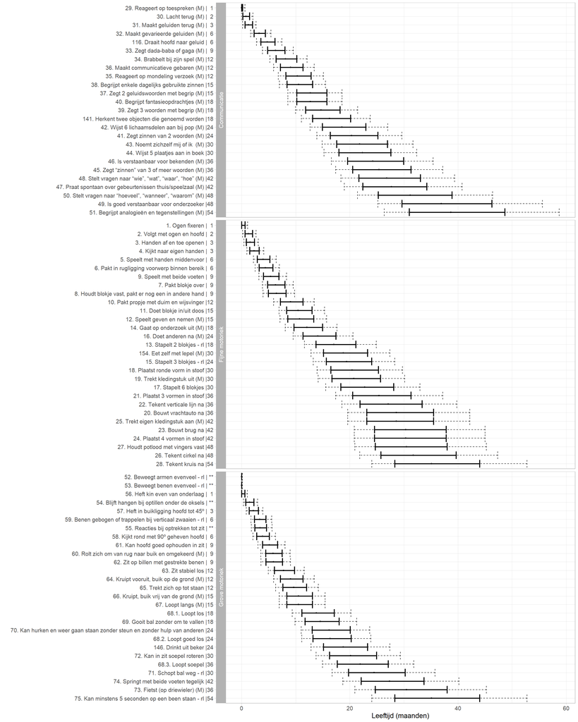

## Geobserveerde data

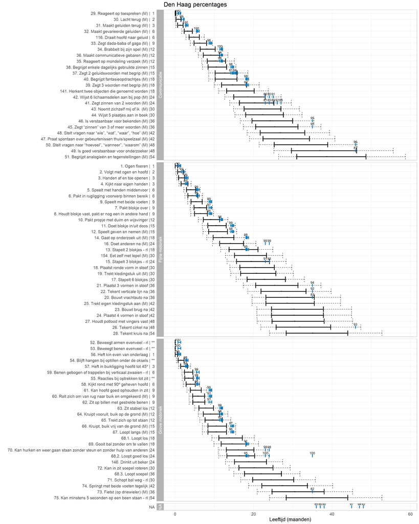

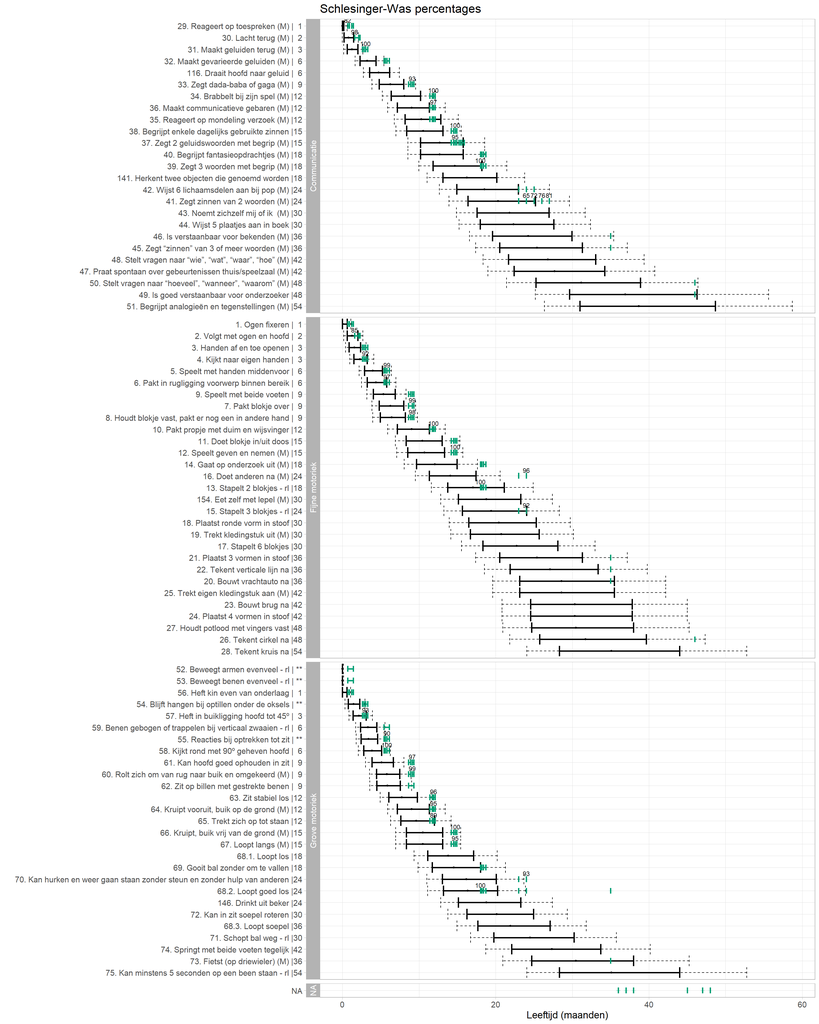

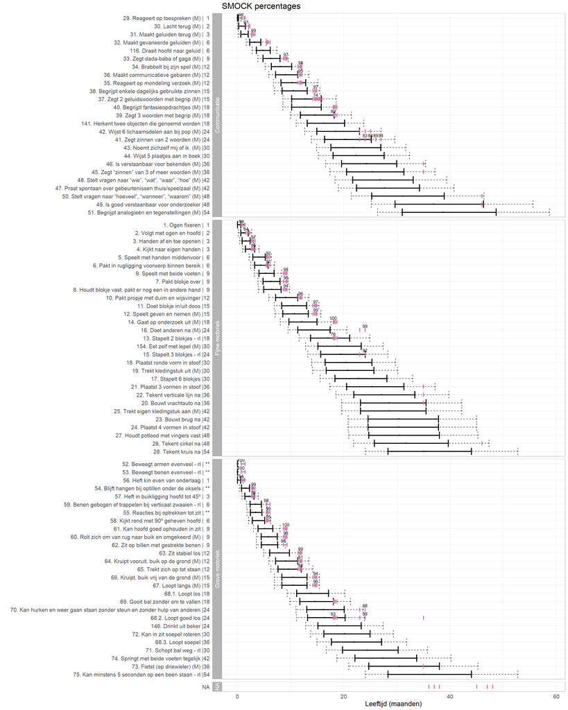

### Update Schlesinger-Was

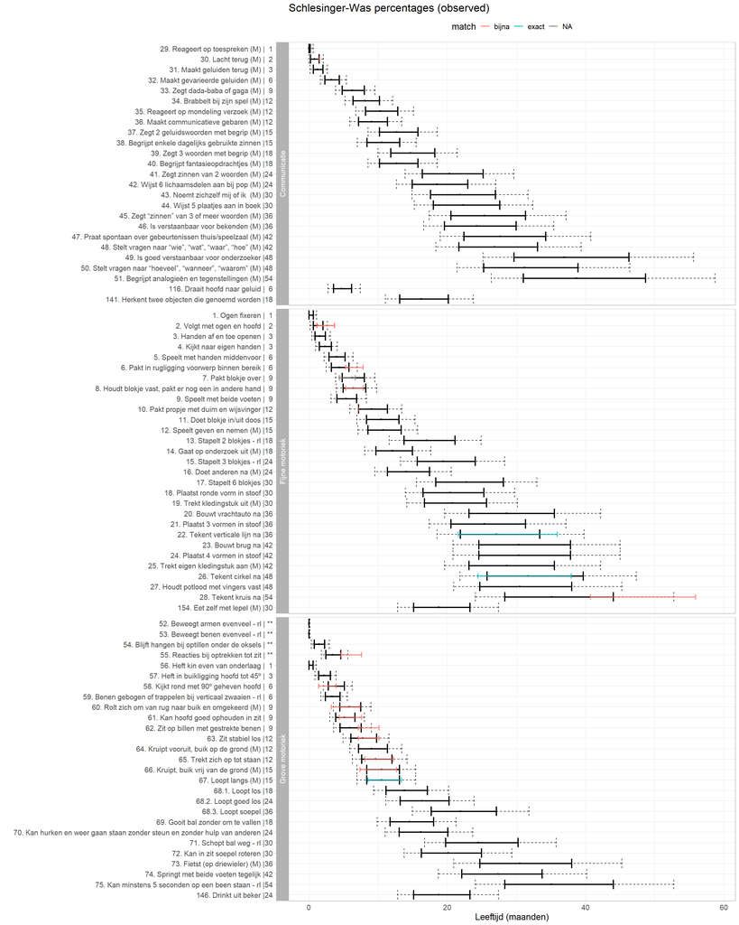

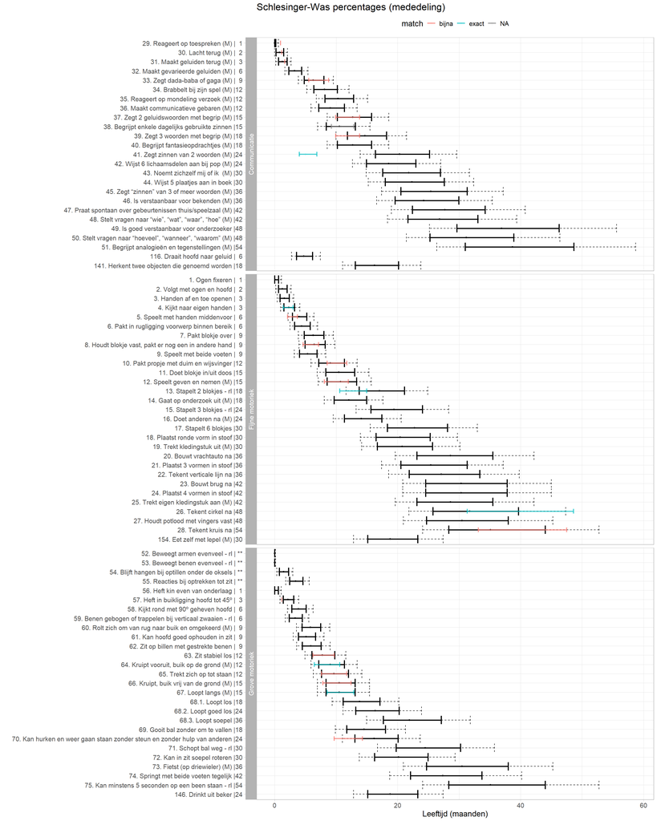

## Overzicht afwijkende kenmerken VWC tov VW-Schema

Kenmerken met de P90 leeftijd NA de VWschema leeftijd

labelNLnr

month

A90

domein

4. Kijkt naar eigen handen

3

3.24

Fijne motoriek

13. Stapelt 2 blokjes - rl

18

21.11

Fijne motoriek

15. Stapelt 3 blokjes - rl

24

24.04

Fijne motoriek

35. Reageert op mondeling verzoek (M)

12

12.82

Communicatie

37. Zegt 2 geluidswoorden met begrip (M)

15

15.74

Communicatie

39. Zegt 3 woorden met begrip (M)

18

18.18

Communicatie

41. Zegt zinnen van 2 woorden (M)

24

25.18

Communicatie

57. Heft in buikligging hoofd tot 45º

3

3.09

Grove motoriek

69. Gooit bal zonder om te vallen

18

18.02

Grove motoriek

71. Schopt bal weg - rl

30

30.21

Grove motoriek

73. Fietst (op driewieler) (M)

36

37.98

Grove motoriek

116. Draait hoofd naar geluid

6

6.15

Communicatie

141. Herkent twee objecten die genoemd worden

18

20.15

Communicatie

Kenmerken met de P98 VOOR de VWschema leeftijd.

labelNLnr

month

A98

domein

9. Speelt met beide voeten

9

8.30

Fijne motoriek

14. Gaat op onderzoek uit (M)

18

17.64

Fijne motoriek

16. Doet anderen na (M)

24

20.59

Fijne motoriek

18. Plaatst ronde vorm in stoof

30

29.75

Fijne motoriek

26. Tekent cirkel na

48

47.34

Fijne motoriek

27. Houdt potlood met vingers vast

48

45.24

Fijne motoriek

28. Tekent kruis na

54

52.77

Fijne motoriek

29. Reageert op toespreken (M)

1

0.60

Communicatie

31. Maakt geluiden terug (M)

3

2.68

Communicatie

32. Maakt gevarieerde geluiden (M)

6

5.41

Communicatie

46. Is verstaanbaar voor bekenden (M)

36

35.41

Communicatie

47. Praat spontaan over gebeurtenissen thuis/speelzaal (M)

42

40.76

Communicatie

48. Stelt vragen naar “wie”, “wat”, “waar”, “hoe” (M)

42

39.39

Communicatie

50. Stelt vragen naar “hoeveel”, “wanneer”, “waarom” (M)

48

46.39

Communicatie

55. Reacties bij optrekken tot zit

6

5.64

Grove motoriek

59. Benen gebogen of trappelen bij verticaal zwaaien - rl

6

5.55

Grove motoriek

60. Rolt zich om van rug naar buik en omgekeerd (M)

9

8.95

Grove motoriek

61. Kan hoofd goed ophouden in zit

9

8.01

Grove motoriek

63. Zit stabiel los

12

11.59

Grove motoriek

68.2. Loopt goed los

24

23.89

Grove motoriek

68.3. Loopt soepel

36

31.83

Grove motoriek

70. Kan hurken en weer gaan staan zonder steun en zonder hulp van anderen

24

23.67

Grove motoriek

72. Kan in zit soepel roteren

30

29.35

Grove motoriek

74. Springt met beide voeten tegelijk

42

40.17

Grove motoriek

75. Kan minstens 5 seconden op een been staan - rl

54

52.77

Grove motoriek

154. Eet zelf met lepel (M)

30

27.41

Fijne motoriek

## Extreme discrepantie

**ddicmm038** en **ddicmm040**

De tau voor ddicmm038 is geinterpoleerd, maar dat is wellicht niet op de goede manier gedaan want deze is veel te hoog geschat. #lineare interpolatie 037[tau=50.1]-039[tau=53.2]

De tau voor ddicmm040 is afgeleid van een ander item dat wel in het model zat onder een andere code en naamgeving: ddicmd148

*Voor deze kenmerken wellicht de tau aanpassen voor VWC. Overleg met Paul.*

Nu zo opgelost:

**ddicmm038: Begrijpt enkele dagelijks gebruikte zinnen**

Het validatie percentage van dit kenmerk is vergelijkbaar met 11. Doet blokje in/uit doos (D-score: 46) en 12. Speelt geven en nemen (D-score: 46.5). De nieuwe schatting staat daarom nu op D-score: 47.

**ddicmm040: Begrijpt fatasieopdrachtjes**

Dit kenmerk zou voor “39. Zegt 3 woorden met begrip” moeten liggen (D-score: 53.2) en lijkt in validatie percentage enigszins op “14. Gaat op onderzoek uit” (D-score: 46.9). De update in schatting heb ik nu tussen deze twee kenmerken gezet op D-score 50.1.